# R3 — Voronoi sui nuclei reali

geo_spatialtrans — report di step (binario R)

Published

October 8, 2026

```r
.libPaths("~/2025.geo_spatialtrans/renv/library/linux-ubuntu-noble/R-4.6/x86_64-pc-linux-gnu")
RES <- "../results/R3"; FIG <- file.path(RES, "figures")
rd <- function(f) read.csv(file.path(RES, f), check.names = FALSE)
k <- function(d, digits = 3) knitr::kable(d, digits = digits, row.names = FALSE)
V <- rd("R3_verdicts.csv"); CS <- rd("R3_cells_summary.csv"); RR <- rd("R3_roi_summary.csv")
```

**Obiettivo unico.** Tassellazione di Voronoi dei centroidi nucleari reali dei 30 ROI R2 (5 per archetipo A1–A6), ritagliata sulla maschera valida (tessuto − bolle): distribuzioni empiriche per archetipo di area ed eq_radius del territorio, N/C, eccentricità e orientazione del territorio, contenimento dei nuclei; quanto il Voronoi «puro» spiega la geometria reale. Riferimento per i check B di S1.3–S1.4.

**Sintesi.**

# 1. Pre-registrazione

Testo integrale: `results/R3/R3_preregistration.md`, commit `3fac4e7`, approvato da Luca il 2026-10-08 («approvo») prima di qualsiasi codice. L’approvazione copre le decisioni D-R3.1–D-R3.3:

- segmentatore di R2b; sensibilità StarDist in A4/A6;
- BL-035 come calibrazione sulle finestre R2b;
- R3 prima di S1.3.

Gli script di metrica, run e analisi sono stati committati **prima** del run sui dati reali (`bc1d1c0`, BL-059). Le soglie non sono state modificate.

**Deviazioni e precisazioni dichiarate** (tutte rilevate o confermate dalla revisione avversariale, `results/R3/R3_review_actions.csv`):

| # | Testo pre-registrato | Implementato | Effetto |
| --- | --- | --- | --- |
| 1 | C-R3.4: «media area normalizzata 1 ± 0.01» | area × λ (normalizzare per la media del campione renderebbe il check tautologico) | più severo |
| 2 | C-R3.3c: «momenti del poligono vs regionprops» | momenti dei **pixel** vs regionprops. La coerenza poligono↔︎pixel è indiretta: entrambi coincidono con l’angolo analitico (C-R3.3b, C-R3.3c) | nessuno sui verdetti |
| 3 | M5 «varianza al posto della deviazione standard» | rapporto delle deviazioni standard al posto delle varianze (l’inverso) | mutante rilevato comunque |
| 4 | CP-4: regione = quadrato ∩ maschera | anche meno le esclusioni di Luca (A6_w2–w4): stessa area per manuale e segmentatore | coerente con R2b |
| 5 | maschere «913×913» | A5 912×912; il codice usa `ncol`, nessun effetto | refuso |
| 6 | — | intensità locale con `leaveoneout = FALSE`; permutazioni con seed per ROI; CV per ROI = sd/media delle interne | specificazioni, non divergenze |

**Difetto trovato e corretto durante il run.** C-R3.8 (eccentricità ricalcolata dai pixel contro il parquet di R2) ha dato FAIL: 8.7e-5 sui nuclei quadrati di Space Ranger, con eccentricità esatta 0. La causa era la cancellazione in E[x²] − c² con coordinate fino a 1 000 µm. Correzione: momenti centrati in due passate (`508a74a`). Dopo la correzione lo scarto è 2.6e-7 (PASS). Nessun verdetto era stato calcolato prima della correzione.

# 2. Check C — correttezza software

```r
cs <- rbind(cbind(set = "sintetico", rd("R3_test_synthetic.csv")), cbind(set = "reale", rd("R3_test_real.csv")),
            cbind(set = "riproducibilità", rd("R3_test_repro.csv")))
k(cs[, c("set", "check", "case", "value", "result", "note")], 6)
```

| set | check | case | value | result | note |
| --- | --- | --- | --- | --- | --- |
| sintetico | C-R3.3a | square_area | 0.000000 | PASS | NA |
| sintetico | C-R3.3a | square_ecc | 0.000000 | PASS | NA |
| sintetico | C-R3.3a | square_sides | 1.000000 | PASS | NA |
| sintetico | C-R3.3a | hex_area | 0.000000 | PASS | NA |
| sintetico | C-R3.3a | hex_ecc | 0.000000 | PASS | NA |
| sintetico | C-R3.3a | hex_sides | 1.000000 | PASS | NA |
| sintetico | C-R3.3b | ellipse_ecc_phi0 | 0.000000 | PASS | NA |
| sintetico | C-R3.3b | ellipse_theta_phi0 | 0.000000 | PASS | NA |
| sintetico | C-R3.3b | ellipse_ecc_phi30 | 0.000000 | PASS | NA |
| sintetico | C-R3.3b | ellipse_theta_phi30 | 0.000000 | PASS | NA |
| sintetico | C-R3.3b | ellipse_ecc_phi60 | 0.000000 | PASS | NA |
| sintetico | C-R3.3b | ellipse_theta_phi60 | 0.000000 | PASS | NA |
| sintetico | C-R3.3b | ellipse_ecc_phi-30 | 0.000000 | PASS | NA |
| sintetico | C-R3.3b | ellipse_theta_phi-30 | 0.000000 | PASS | NA |
| sintetico | C-R3.3b | ellipse_ecc_phi75 | 0.000000 | PASS | NA |
| sintetico | C-R3.3b | ellipse_theta_phi75 | 0.000000 | PASS | NA |
| sintetico | C-R3.4 | csr_mean_area_x_lambda | 0.996370 | PASS | NA |
| sintetico | C-R3.4 | csr_var_norm_area | 0.288867 | PASS | NA |
| sintetico | C-R3.4 | csr_mean_nsides | 5.990663 | PASS | NA |
| sintetico | C-R3.1 | synthetic_ring_area | 0.000000 | PASS | NA |
| sintetico | C-R3.2 | synthetic_ring_gen_in_own | 1.000000 | PASS | NA |
| sintetico | C-R3.3c | ellipse_phi0 | 0.000000 | PASS | NA |
| sintetico | C-R3.3c | ellipse_phi30 | 0.000000 | PASS | NA |
| sintetico | C-R3.3c | ellipse_phi60 | 0.000000 | PASS | NA |
| sintetico | C-R3.3c | ellipse_phi-30 | 0.000000 | PASS | NA |
| sintetico | C-R3.3c | ellipse_phi75 | 0.000000 | PASS | NA |
| sintetico | C-R3.5 | tangent | 0.042353 | PASS | NA |
| sintetico | C-R3.5 | separate | 0.000000 | PASS | NA |
| reale | C-R3.8 | roi_primary_30 | 30.000000 | PASS |  |
| reale | C-R3.1 | real_sum_vs_poly_max | 0.000000 | PASS | 40 tassellazioni |
| reale | C-R3.1 | real_poly_vs_px_max | 0.000000 | PASS |  |
| reale | C-R3.2 | real_gen_in_own_min | 1.000000 | PASS |  |
| reale | C-R3.8 | n_used_eq_independent_count | 0.000000 | PASS | inside.owin su maschera spatstat |
| reale | C-R3.2 | n_territories_eq_n | 0.000000 | PASS |  |
| reale | C-R3.8 | nuc_files_present | 0.000000 | PASS |  |
| reale | C-R3.8 | mask_centroid_vs_parquet_um | 0.000000 | PASS | maschere native = maschere di R2 |
| reale | C-R3.8 | mask_area_vs_parquet_um2 | 0.000000 | PASS |  |
| reale | C-R3.8 | mask_ecc_vs_parquet | 0.000000 | PASS |  |
| reale | C-R3.8 | inputs_md5_recorded | 154.000000 | PASS |  |
| riproducibilità | C-R3.6 | real_md5_identical | 0.000000 | PASS | 160 file confrontati |
| riproducibilità | C-R3.6 | null_md5_identical | 0.000000 | PASS | 1200 file confrontati |
| riproducibilità | C-R3.6 | calib_md5_identical | 0.000000 | PASS | 48 file confrontati |

```r
k(rd("R3_mutants.csv"))
```

| mutant | n_fail | detected |
| --- | --- | --- |
| M1 | 1 | TRUE |
| M2 | 1 | TRUE |
| M3 | 2 | TRUE |
| M4 | 5 | TRUE |
| M5 | 5 | TRUE |

Ogni mutante è stato rilevato dal check costruito per lui:

- M1 (tile permutati) → C-R3.2;
- M2 (niente ritaglio) → C-R3.1;
- M3 (x↔︎y nel contenimento) → C-R3.5;
- M4 (flag interne ignorato) → C-R3.3a;
- M5 (eccentricità) → C-R3.3b.

Il riferimento esterno di C-R3.4 (CSR, varianza dell’area normalizzata 0.289 contro 2/7 = 0.286) è la forma gamma con a = b = 7/2 di Ferenc & Néda 2007 (doi:10.1016/j.physa.2007.07.063).

# 3. Check B — plausibilità biologica (A1–A6)

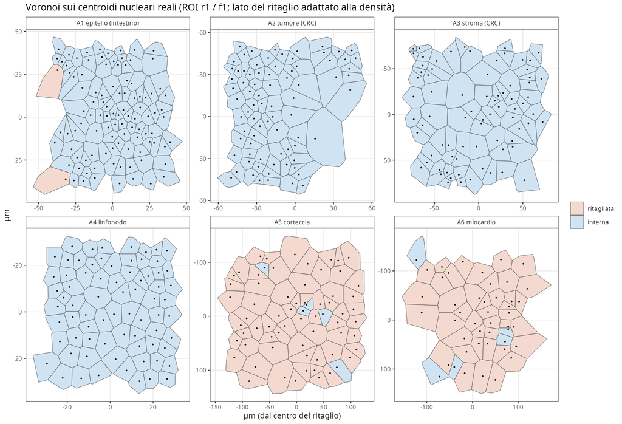

Territori di Voronoi sui centroidi reali (azzurro: interni; rosa: toccati dal ritaglio).

```r
k(CS[, c("archetype", "method", "n_interior", "area_median", "area_q25", "area_q75", "eq_r_median", "nc_median",
         "ratio_median", "ecc_T_median", "spearman_nuc_terr", "frac_cut")])
```

| archetype | method | n_interior | area_median | area_q25 | area_q75 | eq_r_median | nc_median | ratio_median | ecc_T_median | spearman_nuc_terr | frac_cut |
| --- | --- | --- | --- | --- | --- | --- | --- | --- | --- | --- | --- |
| A1 | cellpose_rgb | 33146 | 61.276 | 41.803 | 94.891 | 4.416 | 0.222 | 0.471 | 0.769 | 0.158 | 0.152 |
| A2 | cellpose_rgb | 29937 | 93.953 | 59.276 | 147.629 | 5.469 | 0.356 | 0.597 | 0.729 | 0.377 | 0.275 |
| A3 | cellpose_rgb | 20015 | 167.672 | 90.426 | 298.802 | 7.306 | 0.196 | 0.443 | 0.740 | 0.213 | 0.177 |
| A4 | spaceranger | 136596 | 32.101 | 26.985 | 39.042 | 3.197 | 0.606 | 0.778 | 0.629 | 0.469 | 0.530 |
| A4 | stardist_he | 100062 | 41.728 | 34.394 | 53.458 | 3.645 | 0.384 | 0.620 | 0.660 | 0.379 | 0.011 |
| A5 | cellpose_rgb | 1971 | 819.109 | 497.405 | 1243.494 | 16.147 | 0.098 | 0.312 | 0.761 | 0.366 | 0.025 |
| A6 | spaceranger | 3214 | 742.821 | 487.407 | 1091.517 | 15.377 | 0.028 | 0.168 | 0.783 | 0.140 | 0.041 |
| A6 | stardist_he | 2587 | 876.062 | 575.816 | 1280.048 | 16.699 | 0.026 | 0.160 | 0.777 | 0.105 | 0.010 |

```r
k(V[grepl("^B", V$id), c("id", "archetype", "statistic", "value", "threshold", "assertion", "predicted", "prediction_confirmed", "note")], 4)
```

| id | archetype | statistic | value | threshold | assertion | predicted | prediction_confirmed | note |
| --- | --- | --- | --- | --- | --- | --- | --- | --- |
| B-R3.1 | A1 | eq_r mediano (µm) | 4.4164 | [5, 25] | FAIL | PASS | FALSE |  |
| B-R3.1 | A2 | eq_r mediano (µm) | 5.4686 | [5, 25] | PASS | PASS | TRUE |  |
| B-R3.1 | A3 | eq_r mediano (µm) | 7.3056 | [5, 25] | PASS | PASS | TRUE |  |
| B-R3.1 | A4 | eq_r mediano (µm) | 3.1966 | [5, 25] | FAIL | FAIL | TRUE |  |
| B-R3.1 | A5 | eq_r mediano (µm) | 16.1470 | [5, 25] | PASS | PASS | TRUE |  |
| B-R3.1 | A6 | eq_r mediano (µm) | 15.3770 | [5, 25] | PASS | PASS | TRUE |  |
| B-R3.2 | A1 | rapporto dei raggi mediano | 0.4713 | 0.45 ± 20% | PASS | FAIL | FALSE |  |
| B-R3.2 | A2 | rapporto dei raggi mediano | 0.5966 | 0.45 ± 20% | FAIL | PASS | FALSE |  |
| B-R3.2 | A3 | rapporto dei raggi mediano | 0.4433 | 0.45 ± 20% | PASS | FAIL | FALSE |  |
| B-R3.2 | A4 | rapporto dei raggi mediano | 0.7784 | 0.55 ± 20% | FAIL | PASS | FALSE |  |
| B-R3.2 | A5 | rapporto dei raggi mediano | 0.3124 | nessun valore di catalogo | registrato | registrare | NA |  |
| B-R3.2 | A6 | rapporto dei raggi mediano | 0.1684 | nessun valore di catalogo | registrato | registrare | NA |  |
| B-R3.3a | A4 | N/C mediano | 0.6059 | [0.8, 0.9] | FAIL | FAIL | TRUE |  |
| B-R3.3b | A3 | N/C mediano A3 (vs A1, A2) | 0.1965 | < 0.222 e < 0.356 | PASS | PASS | TRUE |  |
| B-R3.3c | A5 | ROI con dip p < 0.05 (aree territori) | 0.0000 | >= 4/5 | FAIL | FAIL | TRUE | r1 p=0.964; r2 p=0.995; r3 p=0.969; r4 p=0.933; r5 p=0.931 |
| B-R3.4 | A1 | Spearman(area nucleo, area territorio) | 0.1577 | >= 0.3 (regola sostenuta) | FAIL | registrare | NA |  |
| B-R3.4 | A2 | Spearman(area nucleo, area territorio) | 0.3774 | >= 0.3 (regola sostenuta) | PASS | registrare | NA |  |
| B-R3.4 | A3 | Spearman(area nucleo, area territorio) | 0.2131 | >= 0.3 (regola sostenuta) | FAIL | registrare | NA |  |
| B-R3.4 | A4 | Spearman(area nucleo, area territorio) | 0.4688 | >= 0.3 (regola sostenuta) | PASS | registrare | NA |  |
| B-R3.4 | A5 | Spearman(area nucleo, area territorio) | 0.3658 | >= 0.3 (regola sostenuta) | PASS | registrare | NA |  |
| B-R3.4 | A6 | Spearman(area nucleo, area territorio) | 0.1401 | >= 0.3 (regola sostenuta) | FAIL | registrare | NA |  |
| B-R3.4 | tutti | archetipi con regola sostenuta | 3.0000 | <= 2/6 (previsione) | FAIL | PASS | FALSE |  |

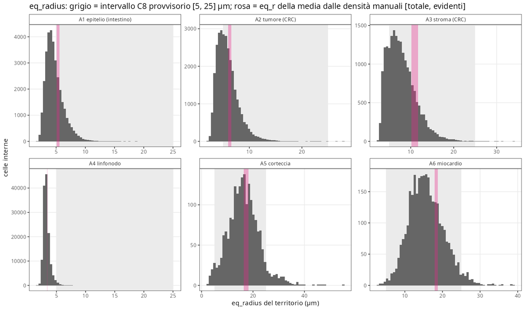

eq_radius dei territori interni; grigio: intervallo C8 provvisorio; rosa: eq_r della media dalle densità manuali.

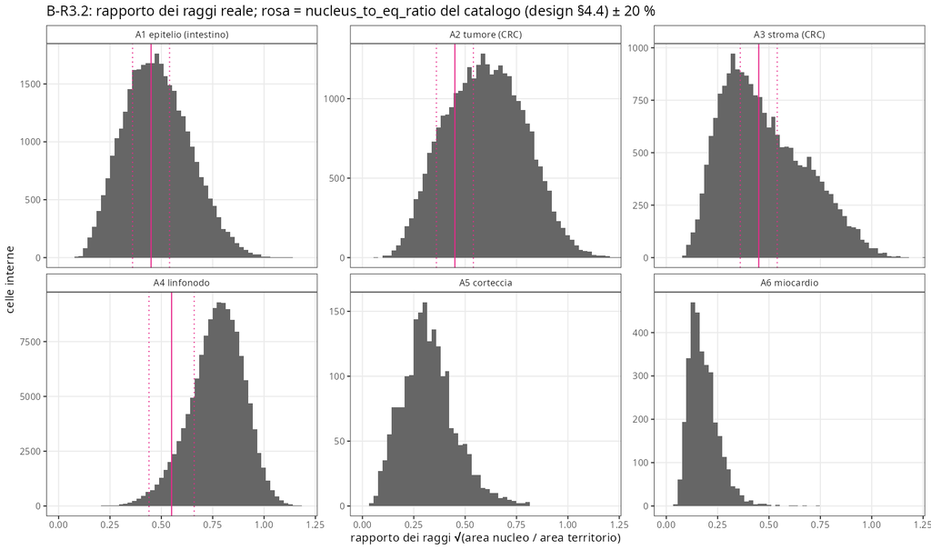

Rapporto dei raggi contro il catalogo del design.

**Lettura.**

**Effetto della selezione delle celle interne** (post hoc P3; revisore claims RA-10/21):

- la frazione di interne è 0.44 in A5 e 0.65 in A6, contro 0.85–0.98 negli altri archetipi;
- le interne di A1 hanno area media pari a 0.82 × quella di tutti i territori;
- i buchi sono nella **maschera di tessuto** (fino a 221 per ROI in A5), non nella maschera bolle: P4, con il ritaglio solo sul tessuto, non cambia A1–A5;
- **conseguenza per S1.3:** i check B devono applicare al simulato la stessa maschera e la stessa regola d’interna (BL-061). Le funzioni sono in `tools/R3_voronoi_metrics.R`.

```r
k(rd("R3_posthoc_P3_interior_bias.csv"))
```

| archetype | method | eq_r_median_all | eq_r_median_interior | eq_r_of_mean_area | frac_interior | mean_area_interior_over_all |
| --- | --- | --- | --- | --- | --- | --- |
| A1 | cellpose_rgb | 4.634 | 4.416 | 5.482 | 0.857 | 0.824 |
| A2 | cellpose_rgb | 5.593 | 5.469 | 6.420 | 0.915 | 0.934 |
| A3 | cellpose_rgb | 7.343 | 7.306 | 8.625 | 0.940 | 0.986 |
| A5 | cellpose_rgb | 15.349 | 16.147 | 17.497 | 0.476 | 1.009 |
| A4 | spaceranger | 3.206 | 3.197 | 3.373 | 0.980 | 0.984 |
| A6 | spaceranger | 16.021 | 15.377 | 17.299 | 0.652 | 0.902 |
| A4 | stardist_he | 3.648 | 3.645 | 3.930 | 0.974 | 0.990 |
| A6 | stardist_he | 17.487 | 16.699 | 18.941 | 0.630 | 0.892 |

# 4. Controprova

## CP-1 — il Voronoi di un processo omogeneo spiega la variabilità delle aree?

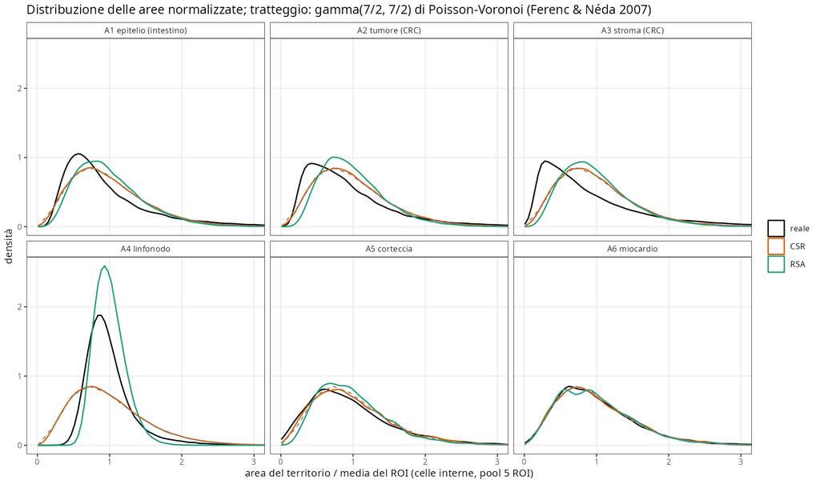

Aree normalizzate: reale contro CSR e RSA(d*), con la gamma di Poisson–Voronoi.

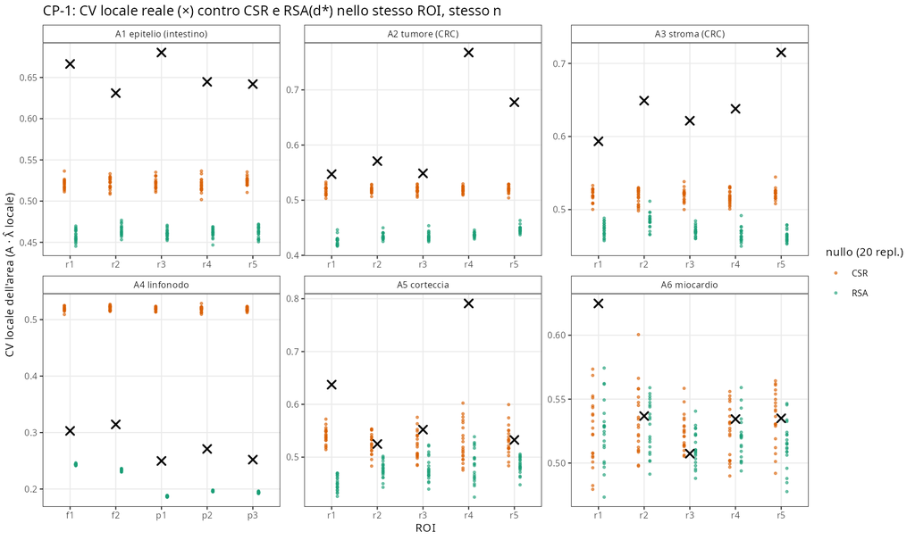

CV locale per ROI: reale (×) contro 20 repliche di CSR e di RSA(d*).

```r
k(rd("R3_cp1_roi.csv")[, c("archetype", "roi_id", "cv_loc_real", "cv_loc_csr_min", "cv_loc_csr_max", "cv_loc_rsa_median", "pos_cvloc_csr", "rel_err_rsa_cvloc")])
```

| archetype | roi_id | cv_loc_real | cv_loc_csr_min | cv_loc_csr_max | cv_loc_rsa_median | pos_cvloc_csr | rel_err_rsa_cvloc |
| --- | --- | --- | --- | --- | --- | --- | --- |
| A1 | r1 | 0.666 | 0.511 | 0.536 | 0.457 | sopra | 0.314 |
| A1 | r2 | 0.631 | 0.509 | 0.533 | 0.463 | sopra | 0.266 |
| A1 | r3 | 0.680 | 0.511 | 0.535 | 0.460 | sopra | 0.323 |
| A1 | r4 | 0.645 | 0.502 | 0.537 | 0.462 | sopra | 0.283 |
| A1 | r5 | 0.642 | 0.511 | 0.535 | 0.463 | sopra | 0.279 |
| A2 | r1 | 0.547 | 0.503 | 0.533 | 0.428 | sopra | 0.219 |
| A2 | r2 | 0.571 | 0.507 | 0.529 | 0.432 | sopra | 0.243 |
| A2 | r3 | 0.549 | 0.505 | 0.530 | 0.433 | sopra | 0.211 |
| A2 | r4 | 0.768 | 0.509 | 0.530 | 0.437 | sopra | 0.431 |
| A2 | r5 | 0.678 | 0.504 | 0.529 | 0.447 | sopra | 0.341 |
| A3 | r1 | 0.593 | 0.500 | 0.533 | 0.473 | sopra | 0.203 |
| A3 | r2 | 0.649 | 0.498 | 0.530 | 0.484 | sopra | 0.254 |
| A3 | r3 | 0.622 | 0.500 | 0.538 | 0.470 | sopra | 0.244 |
| A3 | r4 | 0.638 | 0.501 | 0.532 | 0.463 | sopra | 0.273 |
| A3 | r5 | 0.715 | 0.508 | 0.545 | 0.463 | sopra | 0.353 |
| A4 | f1 | 0.303 | 0.509 | 0.525 | 0.244 | sotto | 0.195 |
| A4 | f2 | 0.314 | 0.514 | 0.527 | 0.233 | sotto | 0.258 |
| A4 | p1 | 0.250 | 0.513 | 0.524 | 0.187 | sotto | 0.252 |
| A4 | p2 | 0.271 | 0.509 | 0.529 | 0.196 | sotto | 0.276 |
| A4 | p3 | 0.252 | 0.512 | 0.523 | 0.194 | sotto | 0.231 |
| A5 | r1 | 0.637 | 0.514 | 0.572 | 0.450 | sopra | 0.295 |
| A5 | r2 | 0.525 | 0.483 | 0.553 | 0.477 | dentro | 0.091 |
| A5 | r3 | 0.552 | 0.484 | 0.576 | 0.474 | dentro | 0.142 |
| A5 | r4 | 0.791 | 0.475 | 0.602 | 0.485 | sopra | 0.386 |
| A5 | r5 | 0.533 | 0.484 | 0.599 | 0.484 | dentro | 0.092 |
| A6 | r1 | 0.625 | 0.479 | 0.573 | 0.526 | sopra | 0.158 |
| A6 | r2 | 0.537 | 0.498 | 0.601 | 0.532 | dentro | 0.008 |
| A6 | r3 | 0.507 | 0.505 | 0.558 | 0.510 | dentro | 0.004 |
| A6 | r4 | 0.534 | 0.490 | 0.556 | 0.521 | dentro | 0.026 |
| A6 | r5 | 0.535 | 0.492 | 0.564 | 0.515 | dentro | 0.038 |

- **A1–A3:** CV locale reale sopra CSR in 15/15 ROI. Nessun processo omogeneo riproduce la dispersione delle aree, nemmeno su una banda di 5 spaziature (BL-051 confermato).
- **A4:** reale più regolare di CSR (5/5), come previsto, ma **meno** regolare di RSA(d*) (0/5 entro ±10 %). Il 22–28 % delle distanze al primo vicino dei centroidi SR è < d* = 4 µm (revisore claims): d* è mal specificato su questi centroidi (BL-050).
- **A5:** CV locale dentro o sopra CSR (0/5 sotto). L’inibizione a corto raggio vista in g(r) (S1.2) non si traduce in aree più regolari: domina l’eterogeneità a scala > 5 spaziature (strati e vasi).
- **A6:** praticamente CSR (1/5 sopra); RSA(d*) entro ±10 % in 4/5.

## CP-2 — A6, controllo negativo: anisotropia dei territori

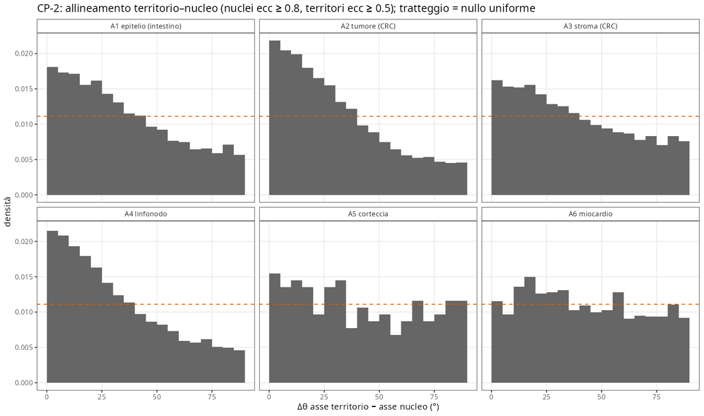

Δθ fra asse del territorio e asse del nucleo.

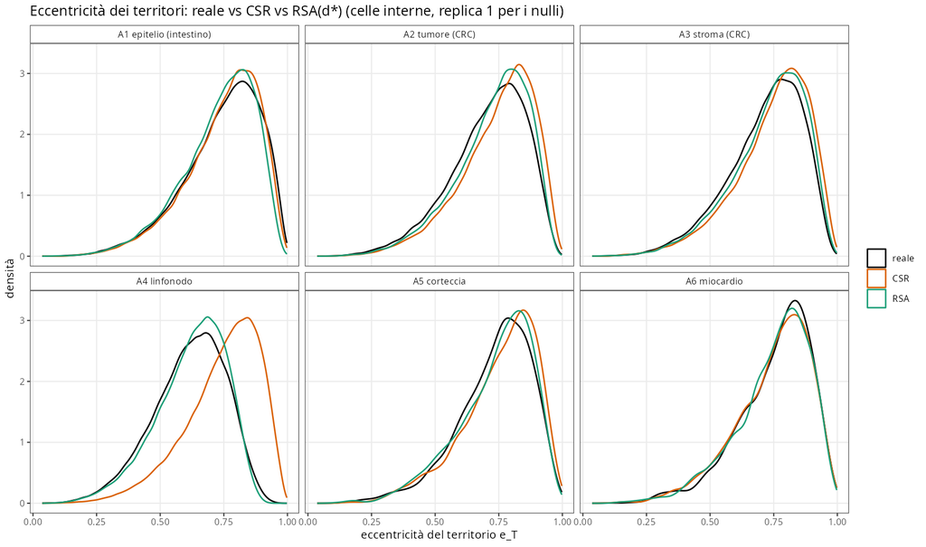

Eccentricità dei territori: reale contro i nulli.

```r
k(rd("R3_cp2_roi.csv")[, c("archetype", "roi_id", "n_eligible", "median_dtheta", "perm_p", "ecc_T_real", "ecc_T_rsa_median", "d_ecc_rsa")])
```

| archetype | roi_id | n_eligible | median_dtheta | perm_p | ecc_T_real | ecc_T_rsa_median | d_ecc_rsa |
| --- | --- | --- | --- | --- | --- | --- | --- |
| A1 | r1 | 3372 | 29.544 | 0.000 | 0.776 | 0.757 | 0.019 |
| A1 | r2 | 2704 | 29.197 | 0.000 | 0.771 | 0.757 | 0.014 |
| A1 | r3 | 3384 | 29.971 | 0.000 | 0.771 | 0.757 | 0.014 |
| A1 | r4 | 2818 | 31.400 | 0.000 | 0.760 | 0.757 | 0.004 |
| A1 | r5 | 3342 | 32.247 | 0.000 | 0.765 | 0.756 | 0.009 |
| A2 | r1 | 2639 | 26.208 | 0.000 | 0.726 | 0.745 | -0.019 |
| A2 | r2 | 2798 | 26.886 | 0.000 | 0.733 | 0.748 | -0.015 |
| A2 | r3 | 2273 | 25.332 | 0.000 | 0.746 | 0.749 | -0.004 |
| A2 | r4 | 2425 | 23.702 | 0.000 | 0.720 | 0.750 | -0.029 |
| A2 | r5 | 2095 | 28.214 | 0.000 | 0.723 | 0.751 | -0.028 |
| A3 | r1 | 1911 | 36.427 | 0.000 | 0.744 | 0.760 | -0.015 |
| A3 | r2 | 1822 | 39.062 | 0.000 | 0.756 | 0.762 | -0.006 |
| A3 | r3 | 2025 | 33.288 | 0.000 | 0.747 | 0.758 | -0.011 |
| A3 | r4 | 1766 | 34.440 | 0.000 | 0.729 | 0.756 | -0.027 |
| A3 | r5 | 1706 | 27.038 | 0.000 | 0.727 | 0.758 | -0.030 |
| A4 | f1 | 2685 | 27.573 | 0.000 | 0.651 | 0.667 | -0.016 |
| A4 | f2 | 2597 | 27.319 | 0.000 | 0.641 | 0.661 | -0.020 |
| A4 | p1 | 2895 | 25.161 | 0.000 | 0.620 | 0.625 | -0.006 |
| A4 | p2 | 2846 | 26.363 | 0.000 | 0.626 | 0.634 | -0.008 |
| A4 | p3 | 2675 | 26.380 | 0.000 | 0.618 | 0.632 | -0.013 |
| A5 | r1 | 81 | 44.031 | 0.254 | 0.760 | 0.760 | -0.001 |
| A5 | r2 | 49 | 33.703 | 0.079 | 0.758 | 0.764 | -0.006 |
| A5 | r3 | 18 | 41.901 | 0.264 | 0.774 | 0.763 | 0.010 |
| A5 | r4 | 19 | 32.579 | 0.041 | 0.764 | 0.765 | -0.001 |
| A5 | r5 | 40 | 36.187 | 0.090 | 0.758 | 0.761 | -0.004 |
| A6 | r1 | 222 | 38.022 | 0.036 | 0.797 | 0.773 | 0.024 |
| A6 | r2 | 219 | 37.400 | 0.214 | 0.786 | 0.781 | 0.005 |
| A6 | r3 | 256 | 45.766 | 0.799 | 0.775 | 0.772 | 0.003 |
| A6 | r4 | 278 | 44.789 | 0.850 | 0.785 | 0.771 | 0.015 |
| A6 | r5 | 308 | 36.812 | 0.328 | 0.776 | 0.773 | 0.003 |

```r
k(rd("R3_posthoc_P1_stardist.csv"))
```

| archetype | roi_id | method | n_eligible | median_dtheta | perm_p | frac_cut | nc_median | ecc_T_median |
| --- | --- | --- | --- | --- | --- | --- | --- | --- |
| A4 | f1 | spaceranger | 2685 | 27.573 | 0.000 | 0.474 | 0.551 | 0.651 |
| A4 | f1 | stardist_he | 827 | 27.003 | 0.000 | 0.011 | 0.345 | 0.677 |
| A4 | f2 | spaceranger | 2597 | 27.319 | 0.000 | 0.502 | 0.577 | 0.641 |
| A4 | f2 | stardist_he | 881 | 24.508 | 0.000 | 0.014 | 0.377 | 0.660 |
| A4 | p1 | spaceranger | 2895 | 25.161 | 0.000 | 0.565 | 0.637 | 0.620 |
| A4 | p1 | stardist_he | 583 | 22.283 | 0.000 | 0.009 | 0.389 | 0.657 |
| A4 | p2 | spaceranger | 2846 | 26.363 | 0.000 | 0.558 | 0.627 | 0.626 |
| A4 | p2 | stardist_he | 700 | 19.561 | 0.000 | 0.012 | 0.391 | 0.662 |
| A4 | p3 | spaceranger | 2675 | 26.380 | 0.000 | 0.536 | 0.619 | 0.618 |
| A4 | p3 | stardist_he | 660 | 19.911 | 0.000 | 0.011 | 0.404 | 0.647 |
| A6 | r1 | spaceranger | 222 | 38.022 | 0.020 | 0.059 | 0.029 | 0.797 |
| A6 | r1 | stardist_he | 157 | 44.081 | 0.295 | 0.017 | 0.021 | 0.802 |
| A6 | r2 | spaceranger | 219 | 37.400 | 0.218 | 0.049 | 0.029 | 0.786 |
| A6 | r2 | stardist_he | 192 | 49.137 | 0.497 | 0.009 | 0.026 | 0.790 |
| A6 | r3 | spaceranger | 256 | 45.766 | 0.772 | 0.027 | 0.022 | 0.775 |
| A6 | r3 | stardist_he | 271 | 44.464 | 0.500 | 0.009 | 0.020 | 0.766 |
| A6 | r4 | spaceranger | 278 | 44.789 | 0.858 | 0.033 | 0.028 | 0.785 |
| A6 | r4 | stardist_he | 310 | 45.915 | 0.848 | 0.009 | 0.027 | 0.778 |
| A6 | r5 | spaceranger | 308 | 36.812 | 0.329 | 0.055 | 0.035 | 0.776 |
| A6 | r5 | stardist_he | 299 | 45.652 | 0.844 | 0.012 | 0.031 | 0.781 |

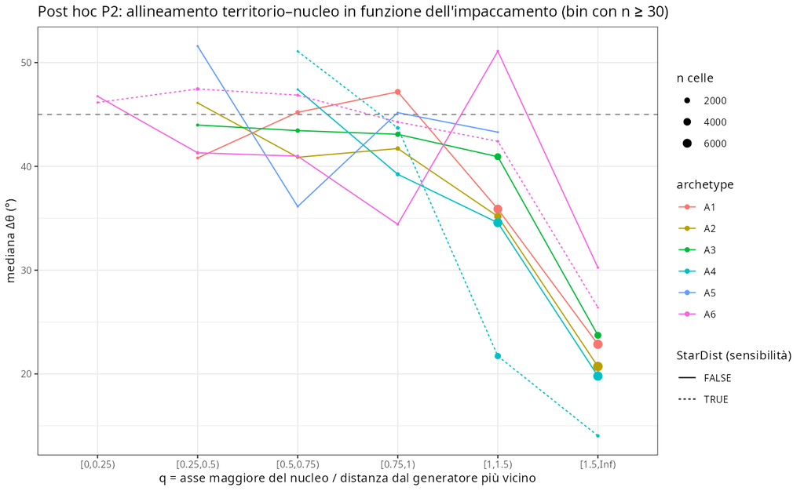

Post hoc P2: l’allineamento cresce con l’impaccamento q.

L’ipotesi del volume escluso (nuclei che non si sovrappongono allontanano i vicini lungo il proprio asse maggiore) è **compatibile con i dati, non dimostrata**:

- q dipende in parte dalla direzione del vicino;
- l’alternativa dell’ordine nematico locale (Δθ fra nuclei vicini 10–17°) non è esclusa;
- serve un nullo con ellissi rigide a orientazione casuale (BL-063).

## CP-3 — il Voronoi taglia i nuclei reali?

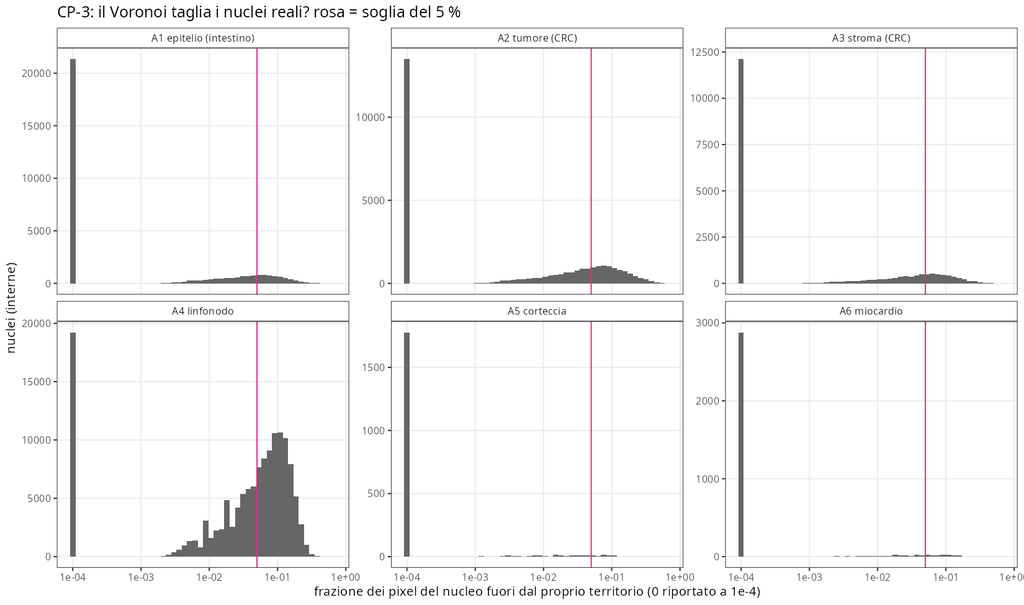

Frazione dei pixel del nucleo fuori dal proprio territorio.

- **Esiti:**
  - A1 15.2 % (previsto ≥ 10 %: PASS); A5 2.5 % (previsto ≤ 5 %: PASS);
  - registrati: A2 27.5 %, A3 17.7 %, A4 53.0 % (SR) / 1.1 % (StarDist), A6 4.1 % (SR) / 1.0 % (StarDist).
- **Revisione avversariale:** CP-3 misura soprattutto la **convenzione di bordo del segmentatore**.
  - A1 scende a 6.3 % erodendo le maschere di un pixel (0.27 µm).
  - In A4 il 93–97 % dei nuclei SR tocca un’altra maschera (bin 2 µm contigui).
  - Il PASS di A1 è quindi fragile; un riferimento richiede contorni manuali (BL-039, BL-062).

## CP-4 — calibrazione BL-035 (finestre R2b)

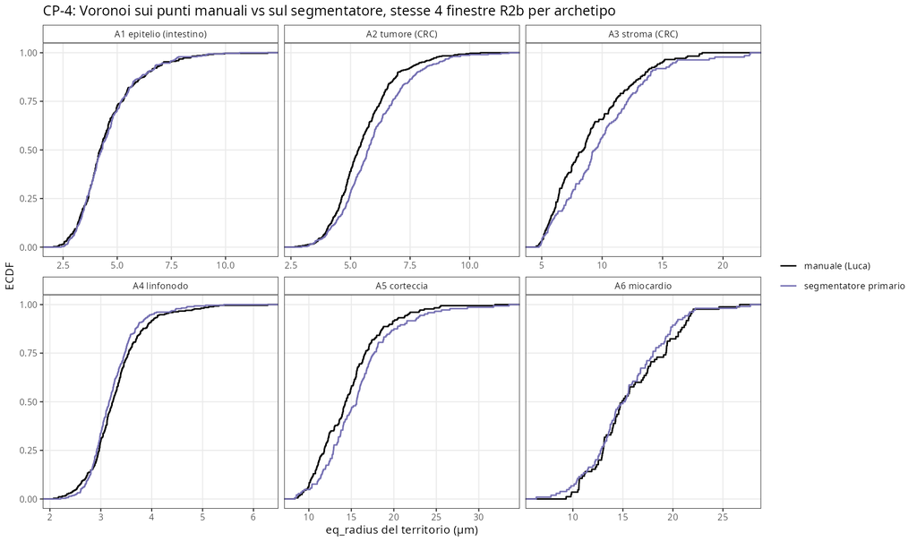

Voronoi sui punti di Luca contro il segmentatore nelle stesse finestre.

```r
k(rd("R3_cp4.csv"))
```

| archetype | n_int_manual | n_int_seg | cv_manual | cv_seg | eq_r_med_manual | eq_r_med_seg | ratio_eqr_seg_over_manual | n_manual | n_seg | conserv_max | sqrt_n_ratio |
| --- | --- | --- | --- | --- | --- | --- | --- | --- | --- | --- | --- |
| A1 | 341 | 337 | 0.713 | 0.666 | 4.201 | 4.275 | 1.018 | 496 | 492 | 0 | 1.004 |
| A2 | 373 | 310 | 0.489 | 0.519 | 5.330 | 5.735 | 1.076 | 513 | 437 | 0 | 1.083 |
| A3 | 172 | 135 | 0.738 | 0.782 | 8.444 | 9.391 | 1.112 | 279 | 243 | 0 | 1.072 |
| A4 | 269 | 283 | 0.372 | 0.307 | 3.234 | 3.163 | 0.978 | 404 | 416 | 0 | 0.985 |
| A5 | 177 | 144 | 0.560 | 0.602 | 14.297 | 15.618 | 1.092 | 296 | 253 | 0 | 1.082 |
| A6 | 85 | 104 | 0.486 | 0.505 | 14.930 | 15.123 | 1.013 | 242 | 264 | 0 | 0.957 |

- **Previsione smentita:** CV_seg > CV_manuale in 4/6 archetipi; A1 e A4 vanno al contrario. L’IC 95 % bootstrap di ΔCV contiene 0 in 6/6 archetipi (revisore claims): con 4 finestre CP-4 non ha potenza (BL-041).
- **Fattore di correzione** di eq_r (segmentatore / manuale): 0.98–1.11, coerente con √(n_manuale/n_seg). Su questo fattore si costruisce l’intervallo [corretto, segmentatore] dei riferimenti.

## Descrittivi

```r
k(rd("R3_descriptive.csv"))
```

| archetype | nn_median_minus_roi_median | clark_evans_cdf_roi_median | clark_evans_min | clark_evans_max | frac_interior_median | mean_area_x_lambda | nsides_mean_real | nsides_var_real | nsides_mean_csr | nsides_var_csr | nsides_mean_rsa | nsides_var_rsa | hed_cover | hed_ratio_median |
| --- | --- | --- | --- | --- | --- | --- | --- | --- | --- | --- | --- | --- | --- | --- |
| A1 | 4.624 | 1.009 | 0.991 | 1.029 | 0.850 | 0.829 | 5.912 | 1.580 | 5.923 | 1.750 | 5.931 | 1.542 | 0.900 | 0.375 |
| A2 | 6.280 | 1.164 | 1.126 | 1.175 | 0.923 | 0.941 | 5.958 | 1.338 | 5.960 | 1.764 | 5.966 | 1.484 | 0.810 | 0.411 |
| A3 | 7.818 | 1.114 | 1.036 | 1.122 | 0.943 | 0.988 | 5.976 | 1.414 | 5.977 | 1.772 | 5.978 | 1.594 | 0.872 | 0.252 |
| A4 | 4.478 | 1.501 | 1.427 | 1.519 | 0.980 | 0.986 | 5.992 | 0.864 | 5.991 | 1.779 | 5.996 | 0.846 | 0.967 | 0.779 |
| A5 | 16.844 | 1.136 | 1.087 | 1.159 | 0.437 | 1.047 | 5.827 | 1.448 | 5.861 | 1.719 | 5.879 | 1.535 | 0.682 | 0.111 |
| A6 | 13.106 | 1.003 | 0.979 | 1.035 | 0.677 | 0.914 | 5.855 | 1.689 | 5.858 | 1.710 | 5.861 | 1.690 | 0.497 | 0.033 |

```r
k(rd("R3_sensitivity.csv"))
```

| case | archetype | n_interior | area_median | eq_r_median | nc_median | ratio_median | ecc_T_median |
| --- | --- | --- | --- | --- | --- | --- | --- |
| A3 senza r3 | A3 | 15945 | 162.988 | 7.203 | 0.201 | 0.448 | 0.739 |
| A4 follicolo (f1, f2) | A4 | 47632 | 35.356 | 3.355 | 0.564 | 0.751 | 0.646 |
| A4 paracorticale (p1–p3) | A4 | 88964 | 30.815 | 3.132 | 0.628 | 0.792 | 0.621 |

- **D-1:** l’oggetto hed contiene il generatore nell’81–97 % dei casi in A1–A4, solo nel 50–68 % in A5–A6; la sua area è 3–78 % del territorio. Come stima del territorio cellulare non è utilizzabile (BL-028).
- **D-2:** Clark–Evans nella forma standard (correzione cdf) va da 1.00 (A1, A6) a 1.50 (A4) e sostituisce le «Clark–Evans» di R2 (BL-054).
- **D-3:** varianza del numero di lati reale contro CSR: 0.86 contro 1.78 in A4, uguale a RSA (0.85); 1.34–1.69 negli altri.

# Verdetto

**Chiuso con riserve.**

- **Riferimenti:** `docs/BIO_REFERENCES.md` B-055…B-090 (6 metriche × 6 archetipi, intervallo [corretto, segmentatore]; sono riferimenti da applicare **con la stessa maschera e la stessa regola d’interna**, BL-061).
- **Riserve:**
  - BL-060: Space Ranger in A4/A6 (orientazione agganciata agli assi, N/C, contenimento) → decisione di Luca;
  - BL-061: selezione delle interne;
  - BL-062: CP-3 dipende dal segmentatore;
  - BL-063: meccanismo dell’allineamento;
  - BL-064: A6 senza riferimento di forma cellulare;
  - BL-065: previsioni con lo stimatore sbagliato;
  - BL-066: intervalli C8 per archetipo;
  - BL-067: convenzione dei bordi;
  - BL-068: eterogeneità delle aree.

# Revisione avversariale

Due sotto-agenti indipendenti hanno lavorato il 2026-10-08 sui dati grezzi e sugli script, senza commit, con le uscite in `results/R3/review/`.

- **code** ha usato un’implementazione Python indipendente (shapely `voronoi_polygons`, momenti per triangoli, punto-in-poligono, CV_loc via FFT) e ha ricalcolato su 40/40 ROI × metodo:
  - n, conservazione, frazione di interne, aree, eq_r, CV, e_T, N/C, nuclei tagliati, Δθ: tutto coincide a precisione di macchina;
  - unica eccezione: 1 nucleo esattamente su un bordo di pixel in A6 r3, e i pareggi del contenimento con centroidi SR;
  - nessun bug trovato; 20 rilievi.
- **claims** ha ricalcolato tutti i 55 verdetti dal testo pre-registrato (55/55 identici) e ha controllato le regole di decisione e i nulli. 24 rilievi, fra cui:
  - premessa di P4 sbagliata (bug di analisi post hoc, accolto);
  - selezione delle interne non neutra;
  - d* mal specificato in A4;
  - CP-3 dominato dalla convenzione di bordo;
  - CP-4 senza potenza;
  - deviazioni di formulazione 1–4 sopra.

Azioni rilievo per rilievo: `results/R3/R3_review_actions.csv`.

```r
k(rd("R3_review_actions.csv"))
```

| id | revisore | oggetto | esito | gravita | azione |
| --- | --- | --- | --- | --- | --- |
| RA-code-01..09 | code | n, conservazione, interne, area, eq_r, CV, e_T, N/C su 40 ROI x metodo (implementazione Python indipendente) | confermato (39/40 identici; A6 r3 1 nucleo su un bordo di pixel) | bassa | registrato; nessun verdetto cambia |
| RA-code-02 / RA-code-01 | code | convenzione centroide (centro del pixel) vs maschera (lati del pixel): 357 centroidi SR A6 esattamente su un bordo | metodo | bassa | BACKLOG BL-067 (stessa convenzione in S1.3) |
| RA-code-10 | code | pareggi nel contenimento con centroidi SR quantizzati (A4 p1 0.564814 vs 0.564847) | discrepanza | bassa | dichiarato nel report |
| RA-code-11 / RA-claims-23 | code+claims | p di permutazione = 0 | metodo | bassa | report: p < 1/2001 |
| RA-code-12/13 / RA-claims-17 | code+claims | allineamento territorio-nucleo: non e’ un artefatto di convenzione ne’ dei centroidi SR (jitter, StarDist) | confermato | — | report §4 CP-2 |
| RA-code-14 / RA-claims-17 | code+claims | orientazione nucleare SR agganciata agli assi (59-65% degli eleggibili entro 5 gradi) | metodo | alta | report: in A4/A6 forma e orientazione nucleare da StarDist; BL-060 |
| RA-code-15 / RA-claims-16 | code+claims | meccanismo: volume escluso compatibile ma non dimostrato; alternativa ordine nematico locale; P2 in parte tautologico | metodo | media | report: CP-2b A1 PASS non letto come palizzata; BL-063 (nullo a ellissi rigide) |
| RA-code-16 / RA-claims-12 | code+claims | A4 dipende dal segmentatore: B-R3.2 FAIL (SR 0.778) -> PASS (StarDist 0.620) | metodo | media | report riporta entrambi; verdetto pre-registrato (SR) invariato; BL-060 |
| RA-code-17/18 | code | CV_loc (banda, leaveoneout) e seed dei nulli | confermato | — | — |
| RA-code-19 | code | numero di lati: vertici di grado 4 contati diversamente da GEOS (rel 5e-5) | discrepanza | bassa | registrato |
| RA-code-20 | code | maschere A5 912x912 (testo: 913x913) | discrepanza (testo) | bassa | report: errata nella pre-registrazione; il codice usa ncol |
| RA-claims-01..03 | claims | 55/55 verdetti ricalcolati identici; regole di decisione conformi; nulli n = osservato, n_failed 0 | confermato | — | — |
| RA-claims-04 | claims | M5 implementa sd al posto della varianza (testo: il contrario) | discrepanza | bassa | report: deviazione di formulazione dichiarata |
| RA-claims-05 | claims | C-R3.3c confronta momenti dei pixel (non del poligono) con regionprops | discrepanza | bassa | report: deviazione dichiarata; coerenza poligono-pixel indiretta via l’angolo analitico (C-R3.3b + C-R3.3c) |
| RA-claims-06 | claims | C-R3.4 media normalizzata per 1/lambda (il testo era tautologico) | discrepanza | bassa | report: deviazione dichiarata |
| RA-claims-07 | claims | C-R3.6 non verificabile al momento della revisione | non verificabile | media | eseguito dopo: 160+1200+48 file md5 identici (R3_test_repro.csv) |
| RA-claims-08 | claims | regione CP-4 meno le esclusioni di Luca (solo nel codice) | discrepanza | bassa | report: deviazione dichiarata |
| RA-claims-09 | claims | B-R3.1 A1: ~55% stimatore della previsione (mediana vs eq_r della media), ~45% selezione delle interne; FAIL regge (4.645 lontano dal bordo) | metodo | media | report §3; BL-065 |
| RA-claims-10/21 | claims | selezione delle interne non neutra (A5 lambda_loc interne/tutte 0.74-1.07); P3 usa un denominatore con aree tagliate | metodo | alta | report §3-4; BL-061: S1.3 deve applicare maschera e regola d’interna identiche al simulato |
| RA-claims-11 | claims | B-R3.2 previsione costruita su un altro stimatore (rapporto delle mediane) | metodo | media | report; BL-065 |
| RA-claims-13 | claims | B-R3.4 per ROI: a maggioranza 2/6 (A5 2/5) | metodo | media | report: verdetto pre-registrato (pool) invariato; sensibilita’ riportata |
| RA-claims-14 | claims | CP-1b A4: 22-28% dei primi vicini SR < d* = 4 µm: d* mal specificato sui centroidi SR | metodo | alta | report; BL-050 aggiornato: non usare d* = 4 in S1.3 senza ristima |
| RA-claims-18 | claims | CP-3 A4: SR 53% artefatto di maschere contigue quantizzate (93-97% a contatto); StarDist 1% limite inferiore | metodo | alta | report: CP-3 misura la convenzione di bordo del segmentatore; BL-062 |
| RA-claims-19 | claims | CP-3 A1 0.152 -> 0.063 con erosione di 1 px | metodo | alta | report: PASS di CP-3 A1 fragile; BL-062 |
| RA-claims-20 | claims | premessa di P4 sbagliata: i buchi in A5 sono nella maschera di tessuto, non della bolla | bug (analisi post hoc) | media | accolto: P4 riformulato (il ritaglio solo-tessuto non cambia A1-A5); anche la verifica diretta di Claude (maschere A5 identiche) lo mostra |
| RA-claims-22 | claims | CP-4: IC95 bootstrap di Delta CV contiene 0 in 6/6 | metodo | media | report: CP-4 senza potenza con 4 finestre (BL-041) |
| RA-claims-24 | claims | B-R3.3c FAIL anche su log/sqrt area | confermato | — | — |

# Riproducibilità

Commit: vedi `docs/sessions/2026-10-08_R3.md`.

```bash
bash R/testing/run_R3.sh       # synthetic mutants real null calib analysis figures repro (~50 min su 40 core)
Rscript --vanilla tools/R3_posthoc.R; .venv/bin/python tools/R3_export_tissue.py; Rscript --vanilla tools/R3_posthoc_P4.R
quarto render reports/R3.qmd
```

Per cellula su `/mnt/micron/geo_spatialtrans/R3/`; md5 degli ingressi in `results/R3/R3_inputs_md5.txt`.